```python
%matplotlib notebook
%run escapeImages.py

from notebook.services.config import ConfigManager
cm = ConfigManager()

cm.update('livereveal', {
              'width': 1600,
              'height': 1080,
              'theme': 'serif',
              'transition': 'zoom',
              'start_slideshow_at': 'selected',
})

# Before presentation: run all image cells, everything else should be cleared

"""
// Change top of notebook
$("body.notebook_app").css("top", "-100px")

// Simulate a click on the "Start Slideshow button
$("#start_livereveal").click()
"""
```

```
'\n// Change top of notebook\n$("body.notebook_app").css("top", "-100px")\n\n// Simulate a click on the "Start Slideshow button\n$("#start_livereveal").click()\n'
```

# Pretty Pictures with Numpy

Making Fractals for Dynamical Systems Research using Numpy and Matplotlib

**Evan Oman**

www.evanoman.com

## About Me

- Masters Degree in “Applied and Computational Mathematics” from UMD
- Currently a Systems/Algorithm Engineer at Black River Systems
  - Work on small research grants for Intelligence, Surveillance + Reconnaisance defense contracts
  - Mix of reading CS/Math papers and implementing prototypes
- Also part time Data Science consultant for financial data consulting company
  - Work with Apache Spark (in Scala), also making a Slackbot

# Dynamical Systems

- Dynamical Systems is the study of the behavior of repeated maps of the form

  *z*<sub>*n*</sub> ↦ *z*<sub>*n* + 1</sub> = *f*<sub>*α*<sub>1</sub>, …, *α*<sub>*n*</sub></sub>(*z*<sub>*n*</sub>)

  where *f*<sub>*α*<sub>1</sub>, …, *α*<sub>*n*</sub></sub> : *S* → *S*
- The ultimate goal would be a characterization of the “long term” behavior of every point *x* ∈ *S* as the parameters *α*<sub>*i*</sub> vary
- My graduate research was focused on the family

  $z_n \mapsto f_{c,\beta} (z_n) = z_n^2 + c + \frac{\beta}{\overline{z_n}^2} = z_{n+1}$

  where *f*<sub>*c*, *β*</sub> : ℂ → ℂ
- This family is interesting because it is non-holomorphic blah, blah, blah…

# Types of Orbits

- The orbit of a some point *x* under some map *f* is the set of points

  Orb(*x*, *f*) = {*x*, *f*(*x*), *f*(*f*(*x*)) = *f*<sup>2</sup>(*x*), …}
- Orbits can be unbounded: ∀*K* ∈ ℝ, ∃*n* ∈ ℕ such that |*f*<sup>*n*</sup>(*x*)| > *K*
  - e.g. 2 under *f*(*x*) = *x*<sup>2</sup>
- Orbits can be bounded (∃*B* such that |*f*<sup>*n*</sup>(*x*)| < *B*, ∀*n* ∈ ℕ)
  - Fixed: 0 under *f*(*x*) = *x*<sup>2</sup> : ${0, 0, …}$
  - Periodic: -1 under *f*(*x*) = *x*<sup>2</sup> − 1 : ${ − 1, 0, − 1, 0, …}$
  - Attracting: 1 under $f(x) = \frac{x}{2}$ : $\{1, \frac{1}{2}, \frac{1}{4}, \frac{1}{8}, \ldots\}$
  - Other: pre-periodic, pre-fixed, CHAOTIC

# Escape Images

- So given some map, we want to be able to get an idea of what the long term behavior is for each of its points as parameters change
- One way to do this is to create an “escape image” which takes each point on the 2D plane as an initial condition (represented by a pixel) and records how long it took for the map, under that initial condition, to escape
- Here is an escape image you might have seen before:

```python
escImgParam(fn=lambda x,c: x*x + c, xmin=-2, xmax=.75, ymin=-1.25,
            ymax=1.25)
```

```
<IPython.core.display.Javascript object>
```

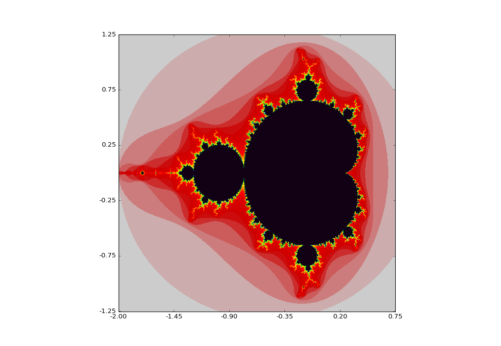

# How to Make the Mandelbrot Set

- The Mandelbrot Set is a Parameter Space Escape Image for the map

  *f*<sub>*c*</sub>(*z*) = *z*<sup>2</sup> + *c*

  such that *f* : ℂ → ℂ
- “Parameter Space” means that each pixel is representing a value for the parameter *c* ∈ ℂ
- So what we need to do is to iterate the map *f*<sub>*c*</sub>(0) some number of times for each pixel (value for *c*) in our plane and determine how “fast” that point escapes
- We then color that pixel with the relative amount of time it took for that point to escape
  - We iterate on the value 0 for technical reasons (it’s special)
  - In this case, “escape” means |*f*<sub>*c*</sub><sup>*n*</sup>(0)| ≥ 2.
  - Thus we are going to color each pixel for the first *n* such that |*f*<sub>*c*</sub><sup>*n*</sup>(0)| > 2
- For this talk I am just using a spectral colormap

[figure not shown]

# How to Make the Mandelbrot Set

- Suppose we wanted to make a $3 × 3$ Mandelbrot Set on the region $[ − 2, 2] × [ − 2, 2]$:

[figure not shown]

# How to Make the Mandelbrot Set

- Now we perform 100 iterations and color each “pixel” with how many iterations it took to get beyond a radius of 2

$\small\left|f_{c = (-2,2i)}(0)\right| = \left|0*0 + (-2,2*i)\right| = \sqrt{(-2)^2 + (2)^2} \\= \sqrt{8} = 2\sqrt{2} \geq 2 \Rightarrow 1 \text{ iteration}$

$\left|f_{c = (0,2i)}(0)\right| = \left|0*0 + (0,2i)\right| = \sqrt{(0)^2 + 2^2} \\= \sqrt{4} = 2 \geq 2\Rightarrow 1 \text{ iteration}$

$\left|f_{c = (2,2i)}(0)\right| = \left|0*0 + (2,2i)\right| = \sqrt{2^2 + (2)^2} \\= \sqrt{8} = 2\sqrt{2} \geq 2 \Rightarrow 1 \text{ iteration}$

$\left|f_{c = (0,0i)}(0)\right| = \left|0*0 + (0,0)\right| = \sqrt{(0)^2 + (0)^2} \\= 0 = \left|f^{100}_{c = (0,0i)}(0)\right| < 2 \Rightarrow 100 \text{ iterations}$  
…  
et cetera

[figure not shown]

# Quickest NumPy Intro

- NumPy is a versatile vector library with lots of cool features:

```python
ex = np.array([1,2,3,4])

# element-wise adition
print(ex + 2)
# vector ops
print(ex * ex)
```

```
[3 4 5 6]
[ 1  4  9 16]
```

```python
# logical indexing
print(ex > 2)
print(ex)
print(ex[ex > 2])
```

```
[False False  True  True]
[1 2 3 4]
[3 4]
```

```python
# Same as the following list comprehension:
def myLog(x, mask):
    return [x_i[0] for x_i in zip(x, mask) if x_i[1]]

print(myLog(ex, ex > 2))
```

```
[3, 4]
```

# How to Make the Mandelbrot Set

- So lets walk though the computation of a $5 × 5$ image
- Credit for Numpy approach: [Dan Goodman](https://thesamovar.wordpress.com/2009/03/22/fast-fractals-with-python-and-numpy/)

```python
# Set all of the initial variables
fn = lambda x,c: x*x + c
critPoint = 0
escapeRad = 2.0
n = 5
m = 5
itermax = 100
xmin = -2
xmax = 2
ymin = -2
ymax = 2
```

# How to Make the Mandelbrot Set

```python
# makes an n*m grid of integers (for indexing)
ix, iy = np.mgrid[0:n, 0:m]

# n evenly spaced points between xmin and xmax
x = np.linspace(xmin, xmax, n)[ix]
y = np.linspace(ymin, ymax, m)[iy]

c = x + complex(0, 1) * y
del x, y  # save a bit of memory, we only need z

# Now lets look inside c:
print(c[0,0])
print(c[1,1])
print(c[2,2])
print(c[3,3])
print(c[4,4])
```

```
(-2-2j)
(-1-1j)
0j
(1+1j)
(2+2j)
```

```python
# Create array of critical points (in this case 0)
img = np.zeros(c.shape, dtype=int)

# Now we flatten these maps
ix.shape = n * m
iy.shape = n * m
c.shape = n * m

# Check contents of c
print(c)
```

```
[-2.-2.j -2.-1.j -2.+0.j -2.+1.j -2.+2.j -1.-2.j -1.-1.j -1.+0.j -1.+1.j
 -1.+2.j  0.-2.j  0.-1.j  0.+0.j  0.+1.j  0.+2.j  1.-2.j  1.-1.j  1.+0.j
  1.+1.j  1.+2.j  2.-2.j  2.-1.j  2.+0.j  2.+1.j  2.+2.j]
```

```python
# Now apply our function (f_c) to all of the points in c
z = fn(critPoint, np.copy(c))

for i in range(itermax):

    # If there aren't any values left, stop iterating
    if not len(z):
        break  # all points have escaped

    # Perform an iteration of our map
    z = fn(z, c)

    # A logical vector specifying the points which have escaped
    rem = abs(z) > escapeRad

    # Store the iteration, i, at which the rem points escaped
    img[ix[rem], iy[rem]] = i + 1

    # Now rem represents the points which have remained bounded
    rem = ~rem

    # Filter out all escaped values
    z, ix, iy, c = z[rem], ix[rem], iy[rem], c[rem]

# sets those points which have not yet escaped to itermax + 1 (which is to say that these points took the longest
#  to escape, or didn't)
img[img == 0] = itermax + 1
```

```python
print(img.T)
```

```
[[  1   1   1   1   1]
 [  1   2 101   1   1]
 [101 101 101   2   1]
 [  1   2 101   1   1]
 [  1   1   1   1   1]]
```

```python
# Reverses the colormap for aesthetic reasons
img = abs(itermax - img)

# create a new figure
fig = plt.figure()

# Does the coloring according to the colormap
image = plt.imshow(img.T, origin='lower left', interpolation="none")
image.set_cmap("nipy_spectral")
```

[output not shown]

```python
# Now we can make the image higher resolution and we get the image we expect
escImgParam(fn = lambda x,c: x*x + c)
```

```
<IPython.core.display.Javascript object>
```

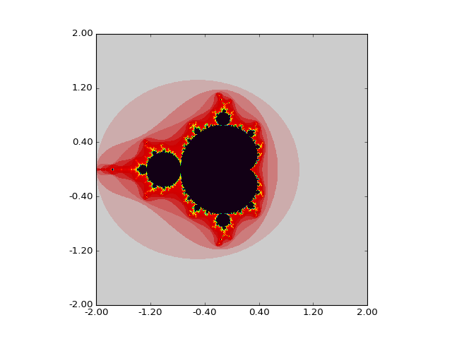

# Other Maps

- The way I have written this this, you can give `escImgParam` any lambda
- Burning Ship: *z* ↦ (|Re(*z*)| + *i*|Im(*z*)|)<sup>2</sup> + *c*

```python
def bShip(z,c): return (abs(np.real(z)) + abs(np.imag(z))*complex(0,1))**2 + c

escImgParam(fn=bShip)
```

```
<IPython.core.display.Javascript object>
```

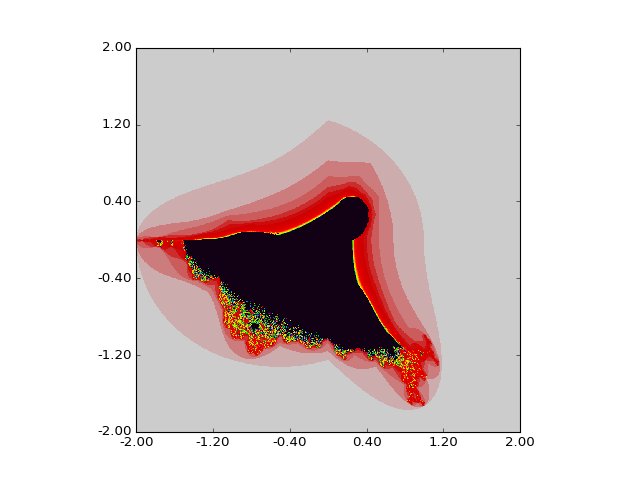

```python
escImgParam(fn=bShip, xmin=-1.8, xmax=-1.5, ymin=-.15, ymax=.15, interp="bicubic", n=1000, m=1000)
```

```
<IPython.core.display.Javascript object>
```

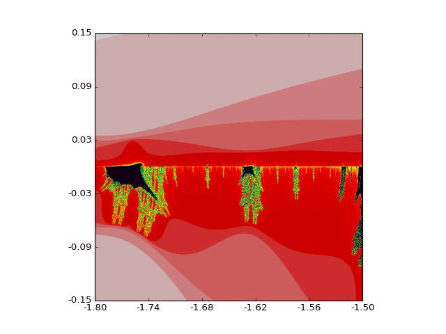

# Conclusion

- The NumPy logical indexing allows Python to perform these operations at almost `C`/`C++` speeds without the need for parallelization
- Lambdas make the Python code extremely flexible for just about any Dynamical System
- Tools used:
  - RISE: https://github.com/damianavila/RISE
  - NumPy: http://www.numpy.org/
  - Matplotlib: http://matplotlib.org

# Questions?

# Escape Image for my Research

My research function: $f_{c,\beta}(z) = z^2 + c + \frac{\beta}{\overline{z}^2}$

```python
r = pow((2/2)*abs(.001), 1.0/(2+2))

#The set of critical points is a circle with the radius given by above, for now we will take the right-most real value on this circle:
critPoint = r*complex(math.cos(0), math.sin(0))

escImgParam(fn=lambda x,c: x*x + c + .001/(np.conj(x)*np.conj(x)), critPoint=critPoint, n=1001, m=1001)
```

```
<IPython.core.display.Javascript object>
```

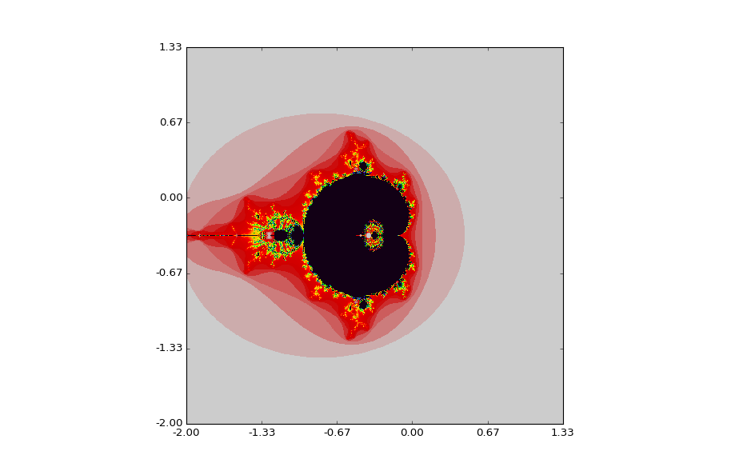